# Multidisciplinary Design Program

# Introduction to Machine Learning

Jeremy Castagno jdcasta@umich.edu

Slides and Code available on Github: https://github.com/JeremyBYU/mdp-machine-learning

01/30/2019

About Me - Jeremy Castagno

- 2013 - BSc. in Chemical Engineering at BYU
- Valero Energy Corporation as process control engineer
- 2016 – Robotics PhD University of Michigan

[figure not shown]

- Topic interests - Artificial Intelligence, Machine Learning, Path Planning, Simulation
- Research topic – Unmanned Aerial System (UAS) emergency rooftop landing in urban cities

[figure not shown]

## What is Machine Learning

- Statistical Learning, Pattern Recognition, Big Data, Data Mining, Expert Systems, Artificial Intelligence (AI), Deep Learning
- Definition- Algorithms and Statistical Models to perform a specific task
- Broadly speaking there are three categories of ML- **supervised** learning, **unsupervised** learning, and **reinforcement** learning
- In this *short* class we will focus only on **supervised** learning
- In almost all cases there is an input (x) and an output (y) for our system

[figure not shown]

There is a true $f(x)$ which we seek to approximate with an $\hat{f}(x)$

**MDP Projects**

- Analyzes $\color{blue}{\text{audio inputs}}$, with a goal of determining factors such as $\color{green}{\text{occupants, locations, and state of vehicle}}$
- Process the $\ldots \color{blue}{\text{road itself}} \ldots$ to identify $\color{green}{\text{free paths or drivable surfaces}}$
- Recognize $\ldots \color{blue}{\text{email}} \ldots$ and direct email to appropriate response functions [classification] as well as $\color{green}{\text{suggesting a generated response}}$

### Simple Classification Example

- Iris dataset - https://archive.ics.uci.edu/ml/datasets/Iris
- Input - Sepal Length, Sepal Width, Petal Length, Petal Width
- Output - Class prediction (Setosa, Veriscolor, Virginica)

[figure not shown]

Image - https://www.datacamp.com/community/tutorials/machine-learning-in-r

[figure not shown]

Robot Gathered distance measurement and sent to a neural network. Output of neural network was a steering angle.

LiDAR Data: 360 Degrees distance measurement

| Angle | 1° | 2° | ... | 358° | 359° |
| --- | --- | --- | --- | --- | --- |
| Distance | 1 | 1.2 | ... | 1.5 | 1.5 |

Steering Angle: 0 -360 degrees

### Basic Terms

- Regression vs Classification
- Regression - Output takes continuous valued variables
- Classification - Output determines group membership (class)
  - Sometimes the output is **both** - Semantic bounding boxes
- Features, predictors, independent variables - text email, audio stream, video stream
  - Iris Classification - Sepal Length, Sepal Width, Petal Length, Petal Width
- Ground Truth Labels - Classes, y
  - Iris Classification - Species Prediction

**Supervised Learning**

Learning a function that maps an *input* ($X$) to and *output* ($Y$), given labeled training data

$$ Y=f(X)+ \underbrace{\epsilon}_{noise} \\ \hat{Y}=\hat{f}(X) $$

$ \mathbf{X}=\overbrace{ \left( \begin{array}{cccc}{x_{11}} & {x_{12}} & {\dots} & {x_{1 p}} \\ {x_{21}} & {x_{22}} & {\dots} & {x_{2 p}} \\ {\vdots} & {\vdots} & {\ddots} & {\vdots} \\ {x_{n 1}} & {x_{n 2}} & {\dots} & {x_{n p}}\end{array}\right)}^{Features}$

$ \mathbf{Y}=\overbrace{\left( \begin{array}{c}{y_{1}} \\ {y_{2}} \\ {\vdots} \\ {y_{n}}\end{array}\right)}^{labels} $

- Main Questions:
  - Should we preprocess our raw data into better features? Text $\implies$ Vector
  - What is the relationship between the response and each feature?
  - What model can be used to estimate f?
    - Parametric Functions - $Y = mx + b$
    - Won't go over non parametric functions in this class

### Assessing Performance

- Training Set and Test Set - Split 60/40
  - Your model should never be trained with the test set
- Regression
  - Mean Squared Error (MSE) = $ MSE=\frac{1}{n} \sum_{i=1}^{n}\left(y_{i}-\hat{f}\left(x_{i}\right)\right)^{2} $
- Classification
  - Training use Logarithmic Loss - $ \frac{-1}{N} \sum_{i=1}^{N} \sum_{j=1}^{M} y_{i j} * \log \left(p_{i j}\right) $
  - Final Assessment
    - Classification Accuracy = $\frac{\text{# of correct pred.}}{\text{Total # of pred.}}$
    - True Positive, True Negative, False Positives, False Negatives

[figure not shown]

Walber [[CC BY-SA 4.0](https://creativecommons.org/licenses/by-sa/4.0)], [from Wikimedia Commons](https://commons.wikimedia.org/wiki/File:Precisionrecall.svg)

[figure not shown]

$ F_{1}=\left(\frac{\text { recall }^{-1}+\text { precision }^{-1}}{2}\right)^{-1}=2 \cdot \frac{\text { precision } \cdot \text { recall }}{\text { precision }+\text { recall }} $

Confusion Matrix

[figure not shown]

- k-Fold cross validation - Train model on subsets of your training data
  - Randomly divide data set into *k* folds of equal size.
  - The first fold is treated as a validation set, the remaining *k* - 1 data is trained on
  - repeat *k* times
  - This results in *k* estimates of validation error
  - $ \mathrm{CV}_{(k)}=\frac{1}{k} \sum_{i=1}^{k} \mathrm{MSE}_{i} $

[figure not shown]

[Source](https://imada.sdu.dk/~marco/Teaching/AY2010-2011/DM825/)

## Simple Regression Model

Goals

- Understand bias/variance tradeoff
- Techniques to prevent overfitting

Question: How would you fit this data?

[figure not shown]

### Bias vs Variance

[figure not shown]

Source: [Scott Fortmann](http://scott.fortmann-roe.com/docs/BiasVariance.html)

$ Y=f(X)+ \underbrace{\epsilon}_{error} $

$\operatorname{Err}(x)=E\left[(Y-\hat{f}(x))^{2}\right] $

$ \operatorname{Err}(x) = \underbrace{\big(E[\hat{f}(x)]-f(x)\big)^{2}}_{\text{Bias}^2}+ \underbrace{E\left[(\hat{f}(x)-E[\hat{f}(x)])^{2}\right]}_{\text{Variance}}+ \underbrace{\operatorname{Var}(\epsilon)}_{\text{Irreducible Error}} $

- Bias indicates a fundamental mismatch between the actual function, $f(x)$, and the estimated function $\hat{f}(x)$
  - Linear model trying to estimate a quadratic function
- Variance refers to the amount by which $\hat{f}$ would change if we trained it on a different sampling of the data set
  - Each $\hat{f}$ would be the same fundamental model, but have different parameters associated with it.
  - In a perfect world these different estimates of $\hat{f}$ would change little.
  - If a model has high variance, small changes in the training data will make big changes in $\hat{f}$
- $\operatorname{Var}(\epsilon)$ is noise in the data and can never be reduced
- As a model becomes more flexible (read complex) then variance will increase and the bias will decrease

```python
interact(plot_interact,  mu=fixed(0), sigma=widgets.IntSlider(min=0,max=30,step=5,value=20),
         num_samples=widgets.IntSlider(min=100,max=500,step=200,value=100),
         visible_lines=[('all', [1, 2, 5, 10]), ('Deg 1', [1]),  ('Deg 2', [2]),  ('Deg 5', [5]),  ('Deg 10', [10])]);
```

[output not shown]

## Simple Classification Example

- Iris dataset - https://archive.ics.uci.edu/ml/datasets/Iris
- Features - Sepal Length, Sepal Width, Petal Length, Petal Width
- Output - Class prediction (Setosa, Veriscolor, Virginica)

[figure not shown]

Image - https://www.datacamp.com/community/tutorials/machine-learning-in-r

View of the Data

```python
df_iris = sns.load_dataset('iris')
display(HTML(df_iris.head().to_html(index=False)))
```

| sepal_length | sepal_width | petal_length | petal_width | species |
| --- | --- | --- | --- | --- |
| 5.1 | 3.5 | 1.4 | 0.2 | setosa |
| 4.9 | 3.0 | 1.4 | 0.2 | setosa |
| 4.7 | 3.2 | 1.3 | 0.2 | setosa |
| 4.6 | 3.1 | 1.5 | 0.2 | setosa |
| 5.0 | 3.6 | 1.4 | 0.2 | setosa |

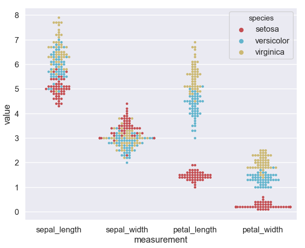

```python
fig, ax = plt.subplots(figsize=(10,8), nrows=1, ncols=1)
sns.swarmplot(x="measurement", y="value", hue="species",
              palette=["r", "c", "y"], data=iris, ax=ax)
```

What are common techniques for separating classes?

- Linear Regression? No!
- Predict a number between 0-2

| Species | Encoding |
| --- | --- |
| Setosa | 0 |
| Veriscolor | 1 |
| Virginica | 2 |

- Whats wrong with this?
- It creates an **ordering** to the classes. The regression learns that *Virginica* is "closer" to *Verisicolor* than *Setosa*.
- Often this ordering is **not** what we want
- One Hot Encoding to the rescue!
- Turn $C$ classes into an **array** of size $C$

| y | Sertosa | Versicolor | Virginica |
| --- | --- | --- | --- |
| Label 1 | 1 | 0 | 0 |
| Label 2 | 0 | 1 | 0 |
| Label 3 | 0 | 0 | 1 |

- Our model should learn to match this vector
- Model output is a probability distribution $\begin{pmatrix}.90 & .05 & .05 \end{pmatrix}$
- If you only have two classes (binary) use one number to represent probability of both classes.

**Classification Models we will learn**

- Logistic Regression
- Support Vector Machines
- Random Forest

**Techniques you should research later**

- XGBoost

### Logistic Regression

#### Logistic Regression - Binary

**Binary Case** (0 or 1)

- $x$ is our feature vector: [Sepal Len, etc..]
- $w$ is a parameter vector. $w_0 x_0 + w_1 x_1 + ... + b = z$
- $\sigma(z)=\frac{1}{1+e^{-z}}$

[figure not shown]

\begin{aligned} z=w^{T} x+b \\ p(y=1)=\sigma(z)=\sigma\left(z\right) \\ z=\log \frac{p(y=1)}{1-p(y=1)} \\ \end{aligned}

\begin{aligned} \operatorname{loss} &=-y \log (\sigma(z))-(1-y) \log (1-\sigma(z)) \\ &=\left\{\begin{array}{ll}{-\log (1-\sigma(z))} & {y=0} \\ {-\log (\sigma(z))} & {y=1}\end{array}\right. \end{aligned}

Minimize the loss by manipulating *w*. Use a solver!

#### Logistic Regression - Multiple Classes

- Assume we have $C$ classes
- One vs all
  - Separately train $C$ *binary* classifiers
  - Select the one with the highest probability
- Multinomial Logistic Regression
  - Use one hot encoding.
  - Train all classifiers together, minimizing their combined loss

### Support Vector Machines

- SVM's separate binary classes through a linear separating hyperplane
- The plane is constructed by solving a global optimization problem
- Maximize the margin $M$ while minimizing misclassified values
- Most data can **not** be separated *completely*, so a tuning parameter, $C$ is used to specify the *slack*

[figure not shown]

#### Kernel Trick

- Some data is not linearly separable from the provided features
- Example - Create **new** features from non-linear combinations of your base features
  - Petal_Width_Length = PetalWidth * PetalLength
  - $\left( \begin{array}{l}{n} \\ {2}\end{array}\right) \text { or }_{n} C_{2}=\frac{n !}{2 !(n-2) !}$
  - 4 Features -> 4 Base Features + 6 new non-linear Features
- Map your feature spaces to higher dimensions, $\Phi(X)$
  - 1000 Features -> 1000 Base featurs + 499,500
  - Too expensive to map and store this data into our feature matrix
- Insight - Separation is done by computing dot products between features
- $K(P(x1,y1),P(x2,y2)) = x_{1}^{2} x_{2}^{2}+y_{1}^{2} y_{2}^{2}+2 x_{1} y_{1} * x_{2} y_{2} $
- $ x_{1}^{2} x_{2}^{2}+y_{1}^{2} y_{2}^{2}+2 x_{1} y_{1} * x_{2} y_{2} = <\left(x_{1}^{2}, y_{1}^{2}, \sqrt{2 x_{1} y_{1}}\right),\left(x_{2}^{2}, y_{2}^{2}, \sqrt{2 x_{2} y_{2}}\right)> $

[figure not shown]

[HackerEarth](https://www.hackerearth.com/blog/machine-learning/simple-tutorial-svm-parameter-tuning-python-r/)

### Decision Trees

- A decision tree is drawn upside down with its root at the top.
- Leaves represent class labels and branches represent conjunctions of features that predict class labels
- Construction - choose a feature at each step that best splits the set of items
  - Entropy
  - Gini
- Repeat this process until all training data is split

[figure not shown]

```python
graph
```

[figure not shown]

#### Random Forests

- Ensemble Learning - A collection of multiple independently trained learning algorithms
- Bagging - Random sampling of training data
- Random feature selection (if there are alot of features)

[figure not shown]

## Break

- Restroom
- Discuss Projects

[figure not shown]

Ruryk [[CC BY-SA 3.0](https://creativecommons.org/licenses/by-sa/3.0)], [from Wikimedia Commons](https://commons.wikimedia.org/wiki/File:Oscillating_pendulum.gif)

## Natural Language Processing

# What makes NLP hard

- Raw data is not in a vector space! Characters are not numbers and don't directly relate to eachother.
  - A lot of great work in transforming text into vector spaces using Deep learning.
- Computer can count patterns and such, but don't innately understand concepts that words and phrases provide.
  - There is a conceptual dimension that must be learned.
  - It's difficult to construct and train a model that does this with language.
- Incredible amount of ambiguity in text, even for a human.

**Techniques we will learn**

- Basic Fundamental Steps of NLP
  - Example - Spam Analysis from SMS Text Messages
- Deeper Feature Extraction - Spacey
  - Word Vectors
  - Part-of-speech tags, Named entity labels

### Basic Fundamentals of NLP

1. Look at data
2. Preprocess Text
3. Tokenization
4. Compute TF-IDF scores
5. Choose and Fit Models
6. Hyperparameter Search with Cross Validation

References: [In Machines We Trust](http://inmachineswetrust.com/posts/sms-spam-filter/), [SKLearn](https://scikit-learn.org/stable/modules/cross_validation.html) [Machine Learning Mastery](https://machinelearningmastery.com/clean-text-machine-learning-python/)

Data set comes from UCI and is a public set of SMS labeled messages

Data breakdown:

| Ham | Spam |
| --- | --- |
| 4825 | 747 |

https://archive.ics.uci.edu/ml/datasets/sms+spam+collection

```python
df_spam.head()
```

|  | Label | Text |
| --- | --- | --- |
| 0 | ham | Go until jurong point, crazy.. Available only ... |
| 1 | ham | Ok lar... Joking wif u oni... |
| 2 | spam | Free entry in 2 a wkly comp to win FA Cup fina... |
| 3 | ham | U dun say so early hor... U c already then say... |
| 4 | ham | Nah I don't think he goes to usf, he lives aro... |

#### Look at Data

```python
display(HTML(df_examples.to_html(index=False)))
```

| Label | Text |
| --- | --- |
| ham | Awesome, I'll see you in a bit |
| ham | Hey j! r u feeling any better, hopeSo hunny. i amnow feelin ill & ithink i may have tonsolitusaswell! damn iam layin in bedreal bored. lotsof luv me xxxx |
| spam | You are guaranteed the latest Nokia Phone, a 40GB iPod MP3 player or a £500 prize! Txt word: COLLECT to No: 83355! IBHltd LdnW15H 150p/Mtmsgrcvd18+ |
| spam | XMAS iscoming & ur awarded either £500 CD gift vouchers & free entry 2 r £100 weekly draw txt MUSIC to 87066 TnC www.Ldew.com1win150ppmx3age16subscription |

#### Preprocess Text

- Encode the ham/spam label as 0 or 1.
- Remove Punctuation
- Leading and Ending White space - ' Hey '
- Replace common occurring text patterns with a single word - Regular Expression
  - 'http://spam.me' --> url
  - '$' '£'& --> 'mnsymb'
  - '55555' -- 'shrtcode'
  - '867-5309' --> 'phonenumber'
  - '88' --> 'number'
- Lower case
- Port Stemmer - 'testing' -> 'test'
- Stop words - 'the', 'a'

```python
preprocess_text('TEXT me at 801-458-3434 to win prize at www.spam.com')
```

```
'text phonenumb win prize url'
```

```python
display(HTML(df_spam.iloc[examples].to_html(index=False)))
```

| Label | Text | clean_text | label_encoded |
| --- | --- | --- | --- |
| ham | Awesome, I'll see you in a bit | awesom i see bit | 0 |
| ham | Hey j! r u feeling any better, hopeSo hunny. i amnow feelin ill & ithink i may have tonsolitusaswell! damn iam layin in bedreal bored. lotsof luv me xxxx | hey j r u feel better hopeso hunni amnow feelin ill ithink may tonsolitusaswel damn iam layin bedreal bore lotsof luv xxxx | 0 |
| spam | You are guaranteed the latest Nokia Phone, a 40GB iPod MP3 player or a £500 prize! Txt word: COLLECT to No: 83355! IBHltd LdnW15H 150p/Mtmsgrcvd18+ | you guarante latest nokia phone number gb ipod mp number player mnsymb number prize txt word collect no shrtcode ibhltd ldnw number h number p mtmsgrcvd number | 1 |
| spam | XMAS iscoming & ur awarded either £500 CD gift vouchers & free entry 2 r £100 weekly draw txt MUSIC to 87066 TnC www.Ldew.com1win150ppmx3age16subscription | xma iscom ur award either mnsymb number cd gift voucher free entri number r mnsymb number weekli draw txt music shrtcode tnc url | 1 |

#### Tokenization

- Our features will be every term (word) of the corpus of all terms in all documents (examples)
- This assumes that each word is linearly independent of another.
- Are you hungry? vs You are hungry!
- Use n-grams
- Are you hungry => 'are', 'you', 'hungry', 'are you', 'you hungry'

#### Compute Term Frequency-Inverse document Frequency (TF-IDF)

- TF-IDF is a weight used to evaluate how important a term is to a document (one example) in the collection (all examples)
- Term Frequency, tf
  - Count of how many times a term occurred in the document
- Inverse Document Frequency
  - Measures how important a term is

    $$ \operatorname{tf}(t,d) = |t \in d| \\ \operatorname{idf}(t, D)=\log \frac{N}{|\{d \in D : t \in d\}|} \\ \operatorname{tfidf}(t, d, D)=\operatorname{tf}(t, d) \cdot \operatorname{idf}(t, D) $$

$N$ is count all documents. $ |\{d \in D : t \in d\}| $ is the number of documents where the term $t$ appears

```python
X_data
```

```
<5572x39201 sparse matrix of type '<class 'numpy.float64'>'
	with 102112 stored elements in Compressed Sparse Row format>
```

$\frac{102112}{218,427,972} = \%0.04 $

#### Choose Models and fit

- Support Vector Machines
- Random Forest
- Each of these models have many different *hyperparameters* to tune
- Start with defaults parameters for models
  - SVM - Kernel=linear, C=1.0
  - Random Forest - Split-gini, number of estimators = 20

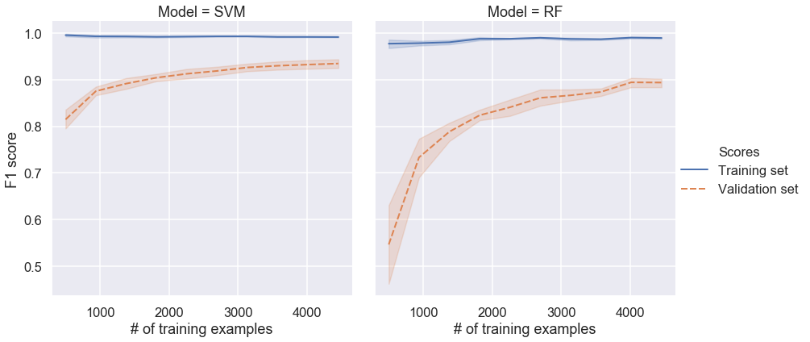

```python
g = sns.relplot(x="# of training examples", y="F1 score",
                hue="Scores", style="Scores", col="Model",
                height=6, aspect=1, kind="line", data=df_compare)
```

#### Hyperparamter Tuning

- There are many hyperparameter to models that can influence their performance
- SVM is influenced by:
  - $C$ - $1e-6, 0.1, 1, 10, 100$
  - Kernel - linear, radial basis function, poly
- We desire to train and validate all **15** combinations of these model parameters
- Choose model with best performance!
- If using python use function called `GridSearchCV` in `sklearn`.

```python
print("Optimal Parameters {}".format(clf.best_params_))
print("Test Score: {:.1f}%".format(test_score * 100))
```

```
Optimal Parameters {'C': 10, 'kernel': 'linear'}
Test Score: 92.6%
```

```python
report
```

|  | f1-score | precision | recall | support |
| --- | --- | --- | --- | --- |
| Ham | 0.989214 | 0.981651 | 0.996894 | 966.0 |
| Spam | 0.925795 | 0.977612 | 0.879195 | 149.0 |
| micro avg | 0.981166 | 0.981166 | 0.981166 | 1115.0 |
| macro avg | 0.957505 | 0.979632 | 0.938045 | 1115.0 |
| weighted avg | 0.980739 | 0.981112 | 0.981166 | 1115.0 |

#### Things to improve

- Remove useless words from model
- Spelling correction?
- Specific TF-IDF implementation didn't normalize against document length
- Better feature extraction

### NLP Advanced Feature Extraction

- Warning - This next part is farther away from my expertise
- There are many state of the art text feature extractors
- [spaCy](https://spacy.io/) - Extremely fast python library
  - Prebuilt models to for large-scale information extraction
  - What is the text about? What is the context? Who, What? When?
  - [Textacy](https://chartbeat-labs.github.io/textacy/getting_started/quickstart.html#working-with-text) - A higher level library that wraps around spaCy
- [AllenNLP](https://allennlp.org/) - GPU accelerated model training
  - Design and evaluate new deep learning models very quickly
- [NLTK](https://www.nltk.org/) - Natural Language Tool Kit
  - "Text processing libraries for classification, tokenization, stemming, tagging, parsing, and semantic reasoning, wrappers for industrial-strength NLP libraries"

Focus on spaCy and some of its capabilities

- Named Entity Recognition
- Similarity

```python
import spacy

nlp = spacy.load('en_core_web_md')
doc = nlp(u'Hi is this JPMC based in London? I need to report credit card fraud')

for ent in doc.ents:
    print(ent.text, ent.label_)
```

```
JPMC PERSON
London GPE
```

```python
tokens = nlp(u'dog cat apple orange')
corr = np.zeros((len(tokens), len(tokens)))
for i, token1 in enumerate(tokens):
    for j, token2 in enumerate(tokens):
        sim = token1.similarity(token2)
        corr[i,j] = sim
df = pd.DataFrame(corr, columns=list(map(str,list(tokens.__iter__()))), index=list(map(str,list(tokens.__iter__()))))
# Generate a mask for the upper triangle
mask = np.zeros_like(df, dtype=np.bool)
mask[np.triu_indices_from(mask)] = True
cmap = sns.color_palette("Blues")

dog_vector = list(tokens.__iter__())[0].vector
```

- You can also convert words into vectors
- Here is an example of the "dog" vector

```python
print("Vector Size: {}".format(dog_vector.shape[0]))
print("First 50 elements: \n ", dog_vector[:50])
```

```
Vector Size: 300
First 50 elements:
  [-0.40176   0.37057   0.021281 -0.34125   0.049538  0.2944   -0.17376
 -0.27982   0.067622  2.1693   -0.62691   0.29106  -0.6727    0.23319
 -0.34264   0.18311   0.50226   1.0689    0.14698  -0.4523   -0.41827
 -0.15967   0.26748  -0.48867   0.36462  -0.043403 -0.24474  -0.41752
  0.089088 -0.25552  -0.55695   0.12243  -0.083526  0.55095   0.3641
  0.15361   0.55738  -0.90702  -0.049098  0.3858    0.38      0.14425
 -0.27221  -0.37016  -0.12904  -0.15085  -0.38076   0.049583  0.12755
 -0.082788]
```

- Here is an example of comparing "dog', "cat", "apple", "orange"

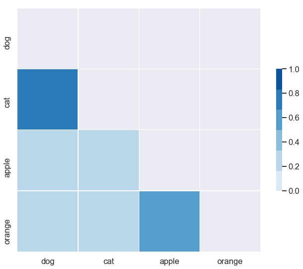

```python
# Draw the heatmap with the mask and correct aspect ratio
f, ax = plt.subplots(figsize=(11, 9))
sns.heatmap(df, mask=mask, cmap=cmap,vmin=0, vmax=1.0,
            square=True, linewidths=.5, cbar_kws={"shrink": .5})
```

```python
df
```

|  | dog | cat | apple | orange |
| --- | --- | --- | --- | --- |
| dog | 1.000000 | 0.801685 | 0.263390 | 0.274251 |
| cat | 0.801685 | 1.000000 | 0.282138 | 0.328847 |
| apple | 0.263390 | 0.282138 | 1.000000 | 0.561892 |
| orange | 0.274251 | 0.328847 | 0.561892 | 1.000000 |

## Break

- Restroom
- Discuss Projects

[figure not shown]

LucasVB [Public domain], [from Wikimedia Commons](https://commons.wikimedia.org/wiki/File:Circle_cos_sin.gif)

## Computer Vision

### Computer Vision Challenges and Advances

- Why is computer vision hard?
- Just like with NLP, vision is more than just about pixels. There are concepts of *things* and *actions*
- There is reasoning and experience involved in matching raw image data to these concepts
- In addition pictures are often very high dimensional

[figure not shown]

Charles J Sharp [[CC BY-SA 4.0](https://creativecommons.org/licenses/by-sa/4.0)]

$$ 256 * 256 * 3 = 196,608 $$

720P = 2,764,800

- There have been some major advances in the field of computer vision over the last 5 years
- Deep learning aided by General-purpose computing on graphics processing units (GPGPU, or GPU)
- Convolutional Neural Network to provide methods of learning high level features

$$ \left[ \begin{array}{rrr}{1} & {0} & {-1} \\ {0} & {0} & {0} \\ {-1} & {0} & {1}\end{array}\right] $$

[figure not shown]

Aphex34 [[CC BY-SA 4.0](https://creativecommons.org/licenses/by-sa/4.0)], [from Wikimedia Commons](https://commons.wikimedia.org/wiki/File:Typical_cnn.png)

[figure not shown]

Aphex34 [[CC BY-SA 4.0](https://creativecommons.org/licenses/by-sa/4.0)], [from Wikimedia Commons](https://commons.wikimedia.org/wiki/File:Typical_cnn.png)

- Object Localization and Detection
  - RCNN
  - Fast RCNN
  - Faster RCNN
  - Yolo
  - SSD

[figure not shown]

Source [YOLO](https://pjreddie.com/darknet/yolo/)

- Image Segmentation
  - FCN
  - Deeplab
  - Others but not deeply familiar with

[figure not shown]

Source [NVIDIA](https://devblogs.nvidia.com/image-segmentation-using-digits-5/)